# Capstone report

Theofilos Papapanagiotou

7 Nov 2014

The progress of the student that explores four languages corpus using Natural Language Processing (NLP) is reported below. The data are loaded, cleaned and an exploratory statistical analysis is applied. For some calculations sampling helps to have a faster result. A technical report including the reproducible code can be obtained from [github](https://github.com/theofpa/datasciencecoursera/blob/master/capstone/report.pdf).

## Data statistics and methodology

The dataset is obtained from Amazon S3 url provided by the instructions, mirrored from the website http://www.corpora.heliohost.org which has the original source of the corpus, maintained by Hans Christensen.

The dataset contains news, blogs and tweets in four different languages, English, German, Russian and Finish.

| dataset | words | characters | lines |
| --- | --- | --- | --- |
| de_DE.blogs.txt | 12,653,185 | 85,459,666 | 371,440 |
| de_DE.news.txt | 13,219,388 | 95,591,959 | 244,743 |
| de_DE.twitter.txt | 11,803,735 | 75,578,341 | 947,774 |
| en_US.blogs.txt | 37,334,690 | 210,160,014 | 899,288 |
| en_US.news.txt | 34,372,720 | 205,811,889 | 1,010,242 |
| en_US.twitter.txt | 30,374,206 | 167,105,338 | 2,360,148 |
| fi_FI.blogs.txt | 12,732,013 | 108,503,595 | 439,785 |
| fi_FI.news.txt | 10,446,725 | 94,234,350 | 485,758 |
| fi_FI.twitter.txt | 3,153,003 | 25,331,142 | 285,214 |
| ru_RU.blogs.txt | 9,691,167 | 116,855,835 | 337,100 |
| ru_RU.news.txt | 9,416,099 | 118,996,424 | 196,360 |
| ru_RU.twitter.txt | 9,542,485 | 105,182,346 | 881,414 |

Apart from the word count statistics, we can also extract other useful information, for example the english has the following statistics:

- Twitter: Small sentence(s), maximum number of characters observed is 213.
- Blogs: Paragraphs. Multiple sentences per blog. Largest sentence has 40835 characters.
- News: Paragraphs. Multiple sentences. Largest sentence has 11384 characters.

The NLP pipeline involves the steps shown below, which this report partially follows.

- End of sentence detection, cleaning.
- Tokenization. In the four languages, tokens can be words or phrases, splitted by space. In the languages that use pictograms, there is no space to seperate the tokens in sentences.
- Profanity filtering.
- Part-of-speech tagging. Tag tokens by nouns, verbs, etc.
- Chunking. Grammar based analysis of the tagged tokens, not statistical analysis.
- Extraction

## Data Exploration

### Acquisition, cleaning, sampling

The load of the data in R has been done in the Corpus data structure, provided by the text mining framework library, tm. That loads the corpus in to the memory.

Data frame is not a good data type to load the text, because it is prone to dimentionality problems. Corpus is using lists.

The cleaning of the datasets has been done as follows:

- Multi-sentenses paragraphs (blog posts, news articles) have been broken to seperate entries in our dataset.
- All capital leters have been transformed to their equivalent lower, (ex. “This” has been transformed to “this”) so our algorithm will summarize their apperence in one key.
- All numbers have been removed since it is not useful for the prediction, and will keep our dataset small.
- Punctuation has been removed, to have the words counted as one key in our algorithm (ex. “this,” will be counted as “this”)
- Whitespaces have been stripped (ex " this " will be counted as “this”)

Although usually the stop-words are removed from a dataset, it has not been followed because we are looking for a predictive model on text, and we don’t want to miss these words.

Instead of importing the whole files in our dataset via the Corpus function, a sample of the data have been used. 100.000 lines per media type (twitter, blogs, news) is enough to safely conclude on the statistics of the english language.

### Tokenization

Multiple functions provide tokenization for R.

- scan_tokenizer() splits the text of the corpus to a character vector, by using the blankspace as the delimiter. Anything between spaces is considered a word.
- MC_tokenizer() splits the text of the corpus to a character vector, and ignores the punctuation, parenthesis, numbers, etc.
- NGramTokenizer() splits a string to n-grams, so we will have not only unigrams (words) like the two tokenizers above can give, but also bigrams, trigrams, etc (phrases of two/three words).

By using the NGramTokenizer method, we calculate the unigrams/bigrams/trigrams for our english corpus, which will be used for our prediction model.

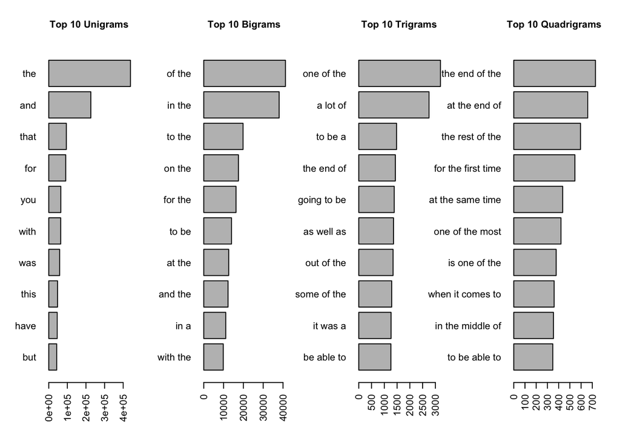

```r
par(mfrow=c(1,4))

ngram <- 1
options(mc.cores=1)
UnigramTokenizer <- function(x) NGramTokenizer(x,Weka_control(min=ngram,max=ngram))
utdm <- TermDocumentMatrix(docs, control = list(tokenize = UnigramTokenizer))
uni<-rowSums(as.matrix(utdm))

ngram <- 2
options(mc.cores=1)
BigramTokenizer <- function(x) NGramTokenizer(x,Weka_control(min=ngram,max=ngram))
btdm <- TermDocumentMatrix(docs, control = list(tokenize = BigramTokenizer))
bi<-rowSums(as.matrix(btdm))

ngram <- 3
options(mc.cores=1)
TrigramTokenizer <- function(x) NGramTokenizer(x,Weka_control(min=ngram,max=ngram))
ttdm <- TermDocumentMatrix(docs, control = list(tokenize = TrigramTokenizer))
tri<-rowSums(as.matrix(ttdm))

ngram <- 4
options(mc.cores=1)
QuadrigramTokenizer <- function(x) NGramTokenizer(x,Weka_control(min=ngram,max=ngram))
qtdm <- TermDocumentMatrix(docs, control = list(tokenize = QuadrigramTokenizer))
qua<-rowSums(as.matrix(qtdm))

barplot(tail(sort(uni),10), las = 2, main = "Top 10 Unigrams",cex.main = 1,horiz=TRUE)
barplot(tail(sort(bi),10), las = 2, main = "Top 10 Bigrams",cex.main = 1,horiz=TRUE)
barplot(tail(sort(tri),10), las = 2, main = "Top 10 Trigrams",cex.main = 1,horiz=TRUE)
barplot(tail(sort(qua),10), las = 2, main = "Top 10 Quadrigrams",cex.main = 1,horiz=TRUE)
```